## We made it! But…

It is not safe to land. Sounds like the Empire is checking all ships for permits. Darn.

There is some good news however. Our rebel comrades also sent along the coordinates of the Empires outposts. And they say that for a small ship like ours, it is technically possible to land undetected. But we have to be able to put down right-dab in the middle of their 3 northern outposts?

> Are you up for a challenge data droid?

Either way, let’s make a map and see what we’re up against. Guess what the first step is? That’s right. It is ime to add a new package.

# Maps with `sf`

### The `sf` package.

[figure not shown]

SF makes maps and spatial analysis in R feel like you’re working with regular table data. It’s full of spatial functions for calculating distances and areas, adding buffers around points, and all of your new dplyr toolbox functions will work as well. It’s great. Let’s get it!

### Install `sf`

**Run:**

```r
install.packages("sf")
```

## Read coordinates

To read in coordinates stored in a spreadsheet or csv, we can read them the same with our usual friends read_csv and read_excel.

**Like this:**

```r
library(readr)

outposts <- read_csv("endor_outposts.csv")

# or
library(readxl)

outposts <- read_excel("endor_outposts.xlsx")
```

Unfortunately, Endor still uses ancient data systems and their spatial data is in a format once known as “shapefiles”. But don’t worry, we can do it all with `st_read()`. It’s a real gem.

**Give it a try:**

```r
library(sf)
library(dplyr)
outposts <- st_read("../../../content/data/endor_outposts.shp", quiet = T)
```

### Let’s take a look

```r
outposts
```

```
## Simple feature collection with 3 features and 3 fields
## Geometry type: POINT
## Dimension:     XY
## Bounding box:  xmin: -1839880 ymin: 4375027 xmax: -1832759 ymax: 4383883
## Projected CRS: NAD83 / UTM zone 15N
##    ID    x_utm   y_utm                 geometry
## 1 1NO -1832921 4383883 POINT (-1832921 4383883)
## 2 1NL -1832759 4375027 POINT (-1832759 4375027)
## 3 3NB -1839880 4378833 POINT (-1839880 4378833)
```

```r
glimpse(outposts)
```

```
## Rows: 3
## Columns: 4
## $ ID       <chr> "1NO", "1NL", "3NB"
## $ x_utm    <dbl> -1832921, -1832759, -1839880
## $ y_utm    <dbl> 4383883, 4375027, 4378833
## $ geometry <POINT [m]> POINT (-1832921 4383883), POINT (-1832759 4375027), POINT (-1~
```

```r
st_coordinates(outposts)
```

```
##          X       Y
## 1 -1832921 4383883
## 2 -1832759 4375027
## 3 -1839880 4378833
```

To make a quick map, tell R to `plot()` the coordinates.

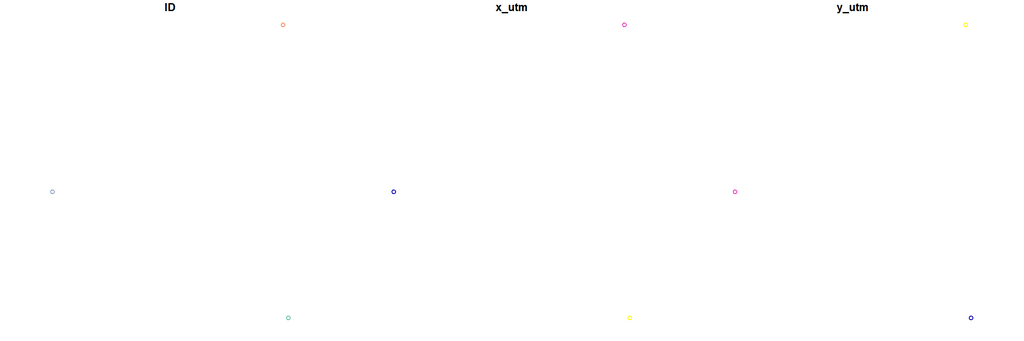

```r
plot(outposts)
```

## Where’s the center?

Do we need some trigonometry? Or can you use the functions we learned yesterday to calculate the center?

`Hint:` How do you find the center of 2 points?

Here’s some code to get you started.

*To calculate a single summary from all the data, we use `summarize()`.*

```r
land_pad <- outposts %>%
            summarize(center_x = ___________,
                      center_y = ___________)
```

**Show code**

```r
land_pad <- outposts %>%
            summarize(center_x = mean(x_utm),
                      center_y = mean(y_utm),
                      ID = "Land Here")
```

## The `st_centroid()` function

```r
land_pad <- outposts %>%
            st_combine %>%
            st_centroid()
```

### We found it!

That’s fantastic. But one more piece of bad news. Endor still uses an outdated coordinate system, and our ship will need coordinates in the WGS84 Lat/Lng format. They generally look like this `(45.6, -93.12)`. For more details see https://epsg.io/4326.

**SF** can help you with this too. Try using `st_transform()` and set the new CRS by adding the argument: `crs = 4326`.

> `crs` = Coordinate reference system

```r
# Transform outposts
outposts <- st_transform(outposts, crs = 4326)

# Transform landing pad
land_pad <- st_transform(land_pad, crs = 4326)
```

### Note

The CRS for the UTM coordinates zone 15N used for Minnesota is `26915`. See https://epsg.io/26915.

We’re going to need to be pretty precise to land perfectly. To make our captain really happy, let’s put this all in an interactive map. That way the pilot can zoom and move around. For interactive maps we use **leaflet**.

## Leaflet maps

### The `leaflet` package.

[figure not shown]

Leaflet makes interactive maps easy and you build them up in layers similar to a ggplot.

### Install `leaflet`

**Run:**

```r
install.packages("leaflet")
```

## Maps that move

### 1. Start with the outpost coordinates

```r
library(leaflet)
leaflet(outposts) %>%
  addCircles(radius = 250) %>%
  addTiles()
```

[interactive chart not shown]

### 2. Add the landing site

```r
leaflet(outposts) %>%
  addCircles(radius = 250) %>%
  addTiles() %>%

  addMarkers(data  = land_pad)  #<<
```

[interactive chart not shown]

### 3. Add labels

```r
leaflet(outposts) %>%
  addCircles(radius = 250,

             label = ~ID) %>%   #<<
  addTiles() %>%
  addMarkers(data  = land_pad,

             label = "Land HERE!",  #<<
             labelOptions = labelOptions(noHide = T))  #<<
```

[interactive chart not shown]

**Wow.** I’m in awe of your work data droid. Let’s just sit here a minute and soak it all in…

Ok, let’s get down on that planet before we’re stuck up here with permanent space legs.